# Mobile App Update Impact and Failure Detection — Review 1

**23CSE452 Business Analytics · Team 10 · Review 1: Data Analysis and Predictive Modelling**

| # | Name | Register number | Stage |
| --- | --- | --- | --- |
| 1 | Aditya Monish Kumar K | CB.SC.U4CSE23103 | Data collection and preprocessing |
| 2 | Regella Krishna Saketh | CB.SC.U4CSE23649 | Exploratory data analysis (with Akshay KS) |
| 3 | Akshay KS | CB.SC.U4CSE23104 | Exploratory data analysis (with Regella Krishna Saketh) |
| 4 | Harshini Vennela | CB.SC.U4CSE23455 | Feature engineering and predictive model (with Kanishka D) |
| 5 | Kanishka D | CB.SC.U4CSE23155 | Feature engineering and predictive model (with Harshini Vennela) |

This notebook runs the Review 1 analysis end to end on our own Play Store data and shows the evidence for each rubric component:

1. Problem statement and dataset description
2. Data cleaning and preprocessing
3. Exploratory data analysis and visualization
4. Feature engineering and dimensionality reduction
5. Predictive model development
6. Model evaluation and result interpretation

The production scripts in `scripts/` do the same steps (and write every chart and table); this notebook recomputes the key numbers so they can be checked. Full write-ups: `DATA_SOURCES.md`, `EDA.md`, `MODEL_EVALUATION.md`, `REPORT.md`.

*Runtime: about 6 minutes on an 8-core laptop (the model training is the slow part). This copy was executed top to bottom in one run.*

```python
import sys, json, time
from pathlib import Path
import numpy as np
import pandas as pd
import matplotlib.pyplot as plt
from IPython.display import Image, display

REPO = Path.cwd().parent if Path.cwd().name == "notebooks" else Path.cwd()
sys.path.insert(0, str(REPO / "scripts"))
from apps import APPS, APP_NAMES, DOMAINS, APP_DOMAIN, APP_COLORS
from data_io import read_stage, read_app

pd.set_option("display.max_colwidth", 110)
pd.set_option("display.width", 160)
plt.rcParams.update({"figure.dpi": 110, "axes.spines.top": False, "axes.spines.right": False})
print("Repository:", REPO.name)
```

```
Repository: ba-capstone-app-reviews
```

## 1. Problem statement and business objective

Swiggy, Zomato, Flipkart, Amazon, Paytm, PhonePe and similar apps receive hundreds of Play Store reviews **every day**, and the busiest more than a thousand. Many report real problems (failed payments, late deliveries, refunds that never arrive, crashes after an update). No team can read them all, so problems — including bad app updates — are noticed late and it is hard to say which problem matters most.

**Research gap.** Published work (Pagano & Maalej 2013; Chen et al. 2014, AR-Miner; Guzman & Maalej 2014; Maalej & Nabil 2015; Hutto & Gilbert 2014, VADER) mostly treats reviews as one fixed set with generic labels ("bug", "feature request") and rarely checks how the collection method biases results.

**Our approach.** Collect every review ourselves, tag domain-specific issues, score sentiment, explore the data with explicit checks for collection artefacts, compare app versions, and train a classifier that flags problem reviews.

**Business objective.** Show which problems hurt users most in each app and domain, whether a new app version made things worse, and automatically surface the reviews that need attention.

## 2. Dataset description

- **Source:** Google Play Store, via the `google-play-scraper` package (calls the Play Store review endpoint; no login). No Kaggle/UCI/GitHub dataset was used.
- **Method:** `scripts/01_scrape_reviews.py` requests reviews with `Sort.NEWEST`, 200 per page, and follows the continuation token backwards in time until a whole page is older than **1 April 2026**, keeping reviews up to **20 September 2026**. So we have **every** English/India review of each app in the window, not a sample.
- **Apps:** 11 apps in 3 domains (list below; single source of truth `scripts/apps.py`).
- **Window:** 1 April – 20 September 2026, identical for every app. Raw data: one gzipped CSV per app in `data/raw/`.

```python
meta = pd.read_csv(REPO / "data" / "app_metadata.csv")
meta["package"] = meta["app_name"].map({a["name"]: a["package"] for a in APPS.values()})
meta[["domain", "app_name", "package", "category", "installs", "current_score"]].sort_values(["domain", "app_name"]).reset_index(drop=True)
```

|  | domain | app_name | package | category | installs | current_score |
| --- | --- | --- | --- | --- | --- | --- |
| 0 | Food & Grocery | Blinkit | com.grofers.customerapp | Food & Drink | 100,000,000+ | 4.575060 |
| 1 | Food & Grocery | Domino's | com.Dominos | Food & Drink | 100,000,000+ | 4.538507 |
| 2 | Food & Grocery | Swiggy | in.swiggy.android | Food & Drink | 100,000,000+ | 4.496276 |
| 3 | Food & Grocery | Zomato | com.application.zomato | Food & Drink | 100,000,000+ | 4.560704 |
| 4 | Payments | Google Pay | com.google.android.apps.nbu.paisa.user | Finance | 1,000,000,000+ | 4.336493 |
| 5 | Payments | Paytm | net.one97.paytm | Finance | 500,000,000+ | 4.669618 |
| 6 | Payments | PhonePe | com.phonepe.app | Finance | 1,000,000,000+ | 4.431528 |
| 7 | Shopping | Amazon | in.amazon.mShop.android.shopping | Shopping | 500,000,000+ | 4.182552 |
| 8 | Shopping | Flipkart | com.flipkart.android | Shopping | 1,000,000,000+ | 4.341977 |
| 9 | Shopping | Meesho | com.meesho.supply | Shopping | 500,000,000+ | 4.384886 |
| 10 | Shopping | Myntra | com.myntra.android | Shopping | 100,000,000+ | 4.601510 |

```python
t0 = time.time()
raw = read_stage("raw", parse_dates=["review_date"])
print(f"Raw dataset: {raw.shape[0]:,} rows x {raw.shape[1]} columns  (loaded in {time.time()-t0:.0f}s)")
print("Review dates:", raw["review_date"].min(), "->", raw["review_date"].max())
raw.dtypes.to_frame("dtype").T
```

```
Raw dataset: 1,202,729 rows x 9 columns  (loaded in 3s)
Review dates: 2026-04-01 00:01:02 -> 2026-09-20 23:59:21
```

|  | app_id | app_name | domain | review_id | score | content | thumbs_up | app_version | review_date |
| --- | --- | --- | --- | --- | --- | --- | --- | --- | --- |
| dtype | str | str | str | str | int64 | str | int64 | str | datetime64[us] |

```python
per_app = raw.groupby(["domain", "app_name"]).agg(raw_reviews=("review_id", "size"),
                                                  first=("review_date", "min"), last=("review_date", "max"))
per_app.sort_values("raw_reviews", ascending=False)
```

| domain | app_name | raw_reviews | first | last |
| --- | --- | --- | --- | --- |
| Shopping | Flipkart | 288063 | 2026-04-01 00:01:02 | 2026-09-20 23:58:55 |
| Food & Grocery | Blinkit | 237716 | 2026-04-01 00:02:31 | 2026-09-20 23:57:33 |
|  | Zomato | 159399 | 2026-04-01 00:03:23 | 2026-09-20 23:56:29 |
| Shopping | Meesho | 107744 | 2026-04-01 00:03:52 | 2026-09-20 23:51:42 |
| Payments | PhonePe | 94101 | 2026-04-01 00:01:19 | 2026-09-20 23:47:12 |
| Shopping | Myntra | 87160 | 2026-04-01 00:08:48 | 2026-09-20 23:59:21 |
| Food & Grocery | Swiggy | 78562 | 2026-04-01 00:03:27 | 2026-09-20 23:55:59 |
| Payments | Paytm | 47940 | 2026-04-01 00:19:39 | 2026-09-20 23:59:00 |
| Food & Grocery | Domino's | 46298 | 2026-04-01 00:03:35 | 2026-09-20 23:56:00 |
| Shopping | Amazon | 34035 | 2026-04-01 00:06:19 | 2026-09-20 23:54:43 |
| Payments | Google Pay | 21711 | 2026-04-01 00:06:10 | 2026-09-20 23:47:43 |

**Coverage.** Reviews per day by app (grey band = the late-April feed gap, see 4.5). Every app has reviews on all 173 days except Zomato (172): it has none from 23 July 22:00 to 25 July 12:30, a gap in the source.

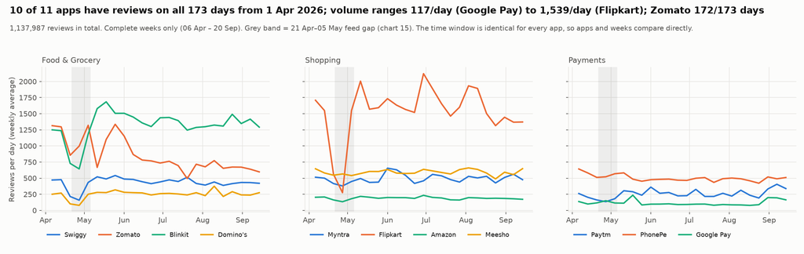

```python
display(Image(REPO / "data/charts/eda/eda_01_coverage.png", width=950))
```

A small sample of the raw data:

```python
raw.sample(6, random_state=7)[["app_name", "score", "content", "thumbs_up", "app_version", "review_date"]]
```

|  | app_name | score | content | thumbs_up | app_version | review_date |
| --- | --- | --- | --- | --- | --- | --- |
| 127382 | Zomato | 5 | easy enterface | 0 | 19.7.7 | 2026-07-13 20:20:01 |
| 883300 | Flipkart | 5 | super | 0 | 9.1 | 2026-04-08 15:28:00 |
| 180420 | Zomato | 5 | Zomoto restaurant is very good and delevery boy is a very faster | 0 | 19.6.3 | 2026-05-21 14:19:19 |
| 356508 | Blinkit | 5 | good work | 0 | 18.7.0 | 2026-06-29 09:22:00 |
| 962313 | Meesho | 1 | not fast delivery | 1 | 28.7 | 2026-08-02 16:52:16 |
| 614998 | Flipkart | 5 | nice | 0 | 9.15 | 2026-09-17 07:15:42 |

**Key variables.** `app_name` / `domain` (category), `score` (1–5 stars), `content` (text), `thumbs_up` (helpful votes), `app_version` (reviewer's installed version), `review_date`.

**Prediction target.** `is_problematic = 1` if `score <= 2`, else 0 (created when the tagged data is loaded at the end of Section 3).

## 3. Data cleaning and preprocessing

Same rules as `scripts/02_clean_reviews.py`, applied here step by step:

1. Remove duplicate `review_id`s.
2. Remove empty or very short reviews (fewer than 3 characters after stripping).
3. Remove reviews with no letters at all (only emojis or punctuation).
4. Remove non-English reviews: fewer than 85% of the **letters** are basic Latin (a–z). Emojis, digits and punctuation are ignored, so an English review such as "good 👍" is kept.
5. Derive `month` and `review_length` (words).

```python
print("Missing values in the raw data:")
print(raw.isna().sum()[lambda s: s > 0])
```

```
Missing values in the raw data:
```

```
content             3
app_version    159239
dtype: int64
```

```python
def latin_letter_ratio(s):
    letters = [c for c in s if c.isalpha()]
    return sum(c.isascii() for c in letters) / len(letters) if letters else 0.0

df = raw.copy()
df["content"] = df["content"].fillna("").astype(str)
steps = [("Raw scraped data", len(df))]

df = df.drop_duplicates(subset="review_id")
steps.append(("Duplicate review_id removed", len(df)))

df = df[df["content"].str.strip().str.len() >= 3]
steps.append(("Empty / < 3 characters removed", len(df)))

df = df[df["content"].map(lambda s: any(c.isalpha() for c in s))]
steps.append(("No letters (emoji/punctuation) removed", len(df)))

df = df[df["content"].map(latin_letter_ratio) >= 0.85]
steps.append(("Non-English (< 85% Latin letters) removed", len(df)))

df["month"] = df["review_date"].dt.to_period("M").astype(str)
df["review_length"] = df["content"].str.split().str.len()

before_after = pd.DataFrame(steps, columns=["step", "rows"])
before_after["removed"] = (-before_after["rows"].diff()).fillna(0).astype(int)
print(f"Columns: {raw.shape[1]} raw -> {df.shape[1]} after cleaning")
before_after
```

```
Columns: 9 raw -> 11 after cleaning
```

|  | step | rows | removed |
| --- | --- | --- | --- |
| 0 | Raw scraped data | 1202729 | 0 |
| 1 | Duplicate review_id removed | 1202729 | 0 |
| 2 | Empty / < 3 characters removed | 1155196 | 47533 |
| 3 | No letters (emoji/punctuation) removed | 1147776 | 7420 |
| 4 | Non-English (< 85% Latin letters) removed | 1137987 | 9789 |

Examples of removed reviews (too short, no letters, non-English):

```python
removed = raw[~raw["review_id"].isin(df["review_id"])]
removed.sample(8, random_state=3)[["app_name", "score", "content"]]
```

|  | app_name | score | content |
| --- | --- | --- | --- |
| 471022 | Blinkit | 5 | 👍👍 |
| 374441 | Blinkit | 5 | 😎 |
| 808375 | Flipkart | 5 | ❤️❤️❤️ |
| 805458 | Flipkart | 5 | ❤️❤️❤️❤️❤️❤️ |
| 1099338 | PhonePe | 5 | ok |
| 73642 | Swiggy | 5 | ബെസ്റ്റ് കസ്റ്റമർ സർവീസ് |
| 826480 | Flipkart | 5 | ok |
| 750331 | Flipkart | 5 | filpkart से शॉपिंग करना ईजी व सुरक्षित है |

**Check:** the cleaned files written by the script (`data/clean/`) have exactly the same rows.

```python
clean_file_ids = read_stage("clean", columns=["review_id"])["review_id"]
assert len(clean_file_ids) == len(df) and set(clean_file_ids) == set(df["review_id"])
print(f"OK: data/clean/*.csv.gz has the same {len(df):,} reviews")
del raw, removed, clean_file_ids
```

```
OK: data/clean/*.csv.gz has the same 1,137,987 reviews
```

**Missing values after cleaning.** Only `app_version` is missing. We keep those rows: version is not a model feature and the text is still valid.

```python
miss = df.isna().sum()
miss[miss > 0].to_frame("missing").assign(pct=lambda t: (t["missing"] / len(df) * 100).round(2))
```

|  | missing | pct |
| --- | --- | --- |
| app_version | 152017 | 13.36 |

**Outliers (Tukey 1.5 × IQR).** We keep all of them: they are real reviews, not errors. We handle them with medians, `log1p` and rank-based statistics instead of deleting the most-seen reviews.

```python
def iqr(x):
    q1, q3 = x.quantile([.25, .75]); hi = q3 + 1.5 * (q3 - q1)
    return pd.Series({"median": x.median(), "upper_fence": hi, "n_above": int((x > hi).sum()),
                      "pct_above": round((x > hi).mean() * 100, 2), "max": x.max()})
pd.DataFrame({c: iqr(df[c]) for c in ["thumbs_up", "review_length"]}).T
```

|  | median | upper_fence | n_above | pct_above | max |
| --- | --- | --- | --- | --- | --- |
| thumbs_up | 0.0 | 0.0 | 72945.0 | 6.41 | 11165.0 |
| review_length | 2.0 | 11.0 | 167193.0 | 14.69 | 167.0 |

**Encoding and scaling** (used in Section 5): review text → TF-IDF; the 9 issue categories are 0/1 columns; the 15 structural features are scaled with `StandardScaler`.

The issue tags and VADER sentiment scores are added by `scripts/03_tag_issues.py` and `scripts/04_sentiment_analysis.py`. We load that enriched dataset for the rest of the analysis.

```python
del df
tagged = read_stage("tagged", parse_dates=["review_date"])
tagged["is_problematic"] = (tagged["score"] <= 2).astype(int)
print(f"Tagged dataset: {tagged.shape[0]:,} rows x {tagged.shape[1] - 1} columns (+ target)")
tagged[["app_name", "score", "content", "review_length", "primary_issue", "sentiment_compound", "sentiment_label"]].sample(5, random_state=11)
```

```
Tagged dataset: 1,137,987 rows x 29 columns (+ target)
```

|  | app_name | score | content | review_length | primary_issue | sentiment_compound | sentiment_label |
| --- | --- | --- | --- | --- | --- | --- | --- |
| 847314 | Flipkart | 1 | worst experience for ever i ordered one item on delivery day i got an message due to unexpected issue the ... | 36 | cancellation_return | -0.7906 | Negative |
| 238292 | Blinkit | 5 | very useful | 2 | none | 0.4927 | Positive |
| 933060 | Meesho | 5 | excellent meesho super discount meesho I love me song | 9 | none | 0.9153 | Positive |
| 1060648 | PhonePe | 5 | Very Nice 💯 | 3 | none | 0.4754 | Positive |
| 320707 | Blinkit | 4 | good | 1 | none | 0.4404 | Positive |

**Issue tags and sentiment scores (text-derived features).** Two rule-based steps turn each comment into numbers before modelling: nine keyword issue tags (`scripts/03_tag_issues.py`) and VADER sentiment (`scripts/04_sentiment_analysis.py`). Both should track the rating if they carry signal:

```python
pd.DataFrame({"% of reviews with an issue tag": tagged.groupby("score")["has_issue"].mean() * 100,
              "mean VADER compound": tagged.groupby("score")["sentiment_compound"].mean(),
              "reviews": tagged.groupby("score").size()}).round(2)
```

| score | % of reviews with an issue tag | mean VADER compound | reviews |
| --- | --- | --- | --- |
| 1 | 48.74 | -0.26 | 196858 |
| 2 | 21.54 | 0.06 | 24723 |
| 3 | 8.22 | 0.28 | 45026 |
| 4 | 2.92 | 0.40 | 114180 |
| 5 | 1.32 | 0.45 | 757200 |

Issue tags are 49% of 1★ reviews against 1% of 5★; VADER compound rises from about −0.26 at 1★ to +0.45 at 5★. Both limits matter later: only 10% of all reviews have a tag (most are too short), and VADER misreads sarcasm and Hinglish.

## 4. Exploratory data analysis and visualization

`scripts/05_eda.py` produces 15 charts (`data/charts/eda/`) and stores every number in `data/eda_summary.json`. Here we recompute the main ones.

### 4.1 Rating mix by app

```python
mix = (pd.crosstab(tagged["app_name"], tagged["score"], normalize="index") * 100).loc[APP_NAMES]
mix["% 1-2 stars"] = mix[1] + mix[2]
mix = mix.round(1)
mix["mean rating"] = tagged.groupby("app_name")["score"].mean().round(2)
mix["public rating"] = meta.set_index("app_name")["current_score"].round(2)
print(f"All apps: {tagged['score'].eq(5).mean()*100:.1f}% 5-star, {tagged['score'].eq(1).mean()*100:.1f}% 1-star, "
      f"median review length {tagged['review_length'].median():.0f} words")
mix.sort_values("% 1-2 stars", ascending=False)
```

```
All apps: 66.5% 5-star, 17.3% 1-star, median review length 2 words
```

| score app_name | 1 | 2 | 3 | 4 | 5 | % 1-2 stars | mean rating | public rating |
| --- | --- | --- | --- | --- | --- | --- | --- | --- |
| Amazon | 50.9 | 3.5 | 3.2 | 5.9 | 36.6 | 54.4 | 2.74 | 4.18 |
| Swiggy | 32.6 | 2.5 | 4.1 | 8.9 | 52.0 | 35.0 | 3.45 | 4.50 |
| Domino's | 21.0 | 2.6 | 4.7 | 9.6 | 62.1 | 23.6 | 3.89 | 4.54 |
| Google Pay | 19.8 | 3.4 | 4.4 | 8.5 | 64.0 | 23.2 | 3.93 | 4.34 |
| Blinkit | 16.5 | 2.5 | 4.3 | 10.7 | 66.0 | 19.0 | 4.07 | 4.58 |
| Zomato | 16.7 | 2.1 | 4.3 | 11.8 | 65.1 | 18.8 | 4.06 | 4.56 |
| Flipkart | 15.7 | 2.6 | 5.5 | 11.8 | 64.4 | 18.3 | 4.07 | 4.34 |
| Meesho | 16.3 | 1.2 | 1.7 | 5.4 | 75.3 | 17.6 | 4.22 | 4.38 |
| Paytm | 13.1 | 1.6 | 2.4 | 6.8 | 76.1 | 14.6 | 4.31 | 4.67 |
| Myntra | 9.5 | 0.8 | 1.2 | 8.0 | 80.5 | 10.3 | 4.49 | 4.60 |
| PhonePe | 8.2 | 1.6 | 3.8 | 11.9 | 74.4 | 9.8 | 4.43 | 4.43 |

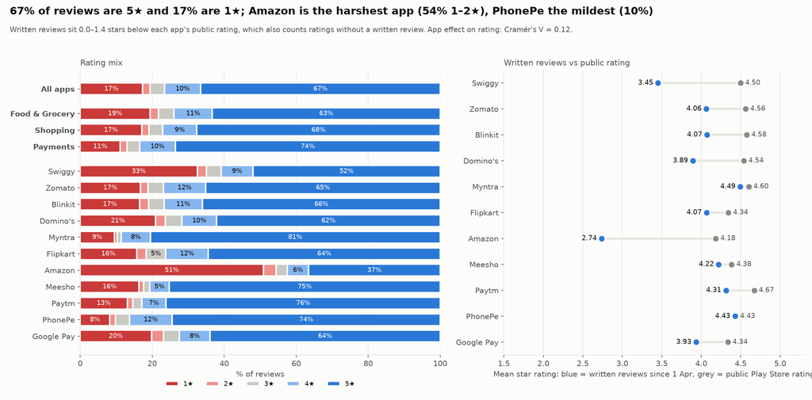

```python
display(Image(REPO / "data/charts/eda/eda_02_ratings_vs_public.png", width=950))
```

**Finding 1.** Amazon (54% of reviews rated 1–2★) and Swiggy (35%) are far harsher than every other app (10–24%). Written reviews also sit below each app's public rating, which includes ratings without text. **Business meaning:** these two apps have a real, lasting service problem; compare apps with each other rather than quoting absolute satisfaction.

### 4.2 Issues by app and domain

```python
ISSUES = ["crash_bugs_stability", "payment_refund", "delivery_delay", "order_quality_fulfillment", "cancellation_return",
          "customer_support", "account_login_otp", "pricing_charges_fraud", "ui_ux_update"]
prev = (tagged.groupby("app_name")[[f"issue_{i}" for i in ISSUES]].mean() * 100).loc[APP_NAMES].T.round(1)
prev.index = [i.replace("issue_", "") for i in prev.index]
prev
```

| app_name | Swiggy | Zomato | Blinkit | Domino's | Myntra | Flipkart | Amazon | Meesho | Paytm | PhonePe | Google Pay |
| --- | --- | --- | --- | --- | --- | --- | --- | --- | --- | --- | --- |
| crash_bugs_stability | 0.6 | 0.2 | 0.3 | 0.5 | 0.3 | 0.4 | 2.0 | 0.4 | 2.2 | 0.5 | 2.7 |
| payment_refund | 4.1 | 1.7 | 1.5 | 1.1 | 1.5 | 1.0 | 7.4 | 2.0 | 0.6 | 0.4 | 1.1 |
| delivery_delay | 6.1 | 3.2 | 2.9 | 3.3 | 2.2 | 2.6 | 8.9 | 2.7 | 0.1 | 0.1 | 0.1 |
| order_quality_fulfillment | 1.9 | 1.0 | 1.2 | 0.7 | 0.9 | 0.6 | 2.8 | 0.9 | 0.0 | 0.0 | 0.0 |
| cancellation_return | 5.3 | 1.5 | 2.3 | 2.0 | 4.9 | 3.2 | 12.5 | 5.5 | 0.4 | 0.1 | 0.4 |
| customer_support | 9.9 | 4.5 | 3.0 | 3.9 | 3.7 | 3.4 | 16.8 | 3.8 | 1.8 | 0.9 | 1.6 |
| account_login_otp | 0.2 | 0.0 | 0.0 | 0.1 | 0.1 | 0.2 | 0.8 | 0.5 | 0.5 | 0.2 | 0.4 |
| pricing_charges_fraud | 3.5 | 2.1 | 1.5 | 1.0 | 1.3 | 1.4 | 4.1 | 1.7 | 1.0 | 0.6 | 1.3 |
| ui_ux_update | 0.2 | 0.1 | 0.1 | 0.1 | 0.3 | 0.1 | 0.8 | 0.1 | 0.5 | 0.2 | 0.7 |

```python
by_issue = pd.DataFrame({i: {"% of reviews": tagged[f"issue_{i}"].mean() * 100,
                             "mean rating with issue": tagged.loc[tagged[f"issue_{i}"] == 1, "score"].mean()} for i in ISSUES}).T
by_issue.round(2).sort_values("% of reviews", ascending=False)
```

|  | % of reviews | mean rating with issue |
| --- | --- | --- |
| customer_support | 4.07 | 1.23 |
| cancellation_return | 3.09 | 1.50 |
| delivery_delay | 2.81 | 1.57 |
| payment_refund | 1.65 | 1.38 |
| pricing_charges_fraud | 1.64 | 1.42 |
| order_quality_fulfillment | 0.91 | 1.24 |
| crash_bugs_stability | 0.53 | 1.78 |
| account_login_otp | 0.19 | 1.45 |
| ui_ux_update | 0.18 | 2.74 |

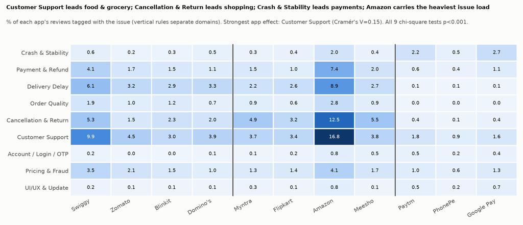

```python
display(Image(REPO / "data/charts/eda/eda_06_issue_by_app.png", width=950))
```

**Finding 2.** Customer Support is the most common issue (4.1% of reviews) and the most damaging (1.23★). Shopping apps are led by Cancellation & Return, Food & Grocery by Customer Support and Delivery Delay; delivery problems are almost absent in Payments. Amazon has the highest rate of nearly every issue. Only 10% of reviews have any issue tag, because most reviews are only 1–3 words. **Business meaning:** one common fix will not work — each company should fix its own top problem first.

**Issue size vs severity (chart 05) and the domain comparison (chart 12).** Customer Support is the most common issue and also the most damaging; each domain has its own top issue (Food & Grocery: Customer Support; Shopping: Cancellation & Return; Payments: Crash & Stability and Customer Support, tied).

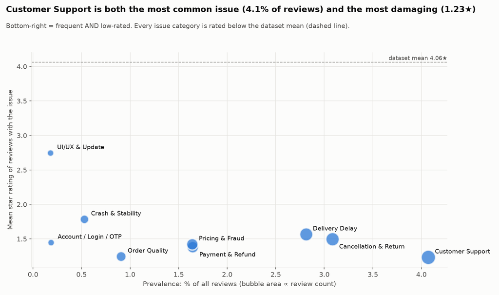

```python
display(Image(REPO / "data/charts/eda/eda_05_issue_priority.png", width=950))
```

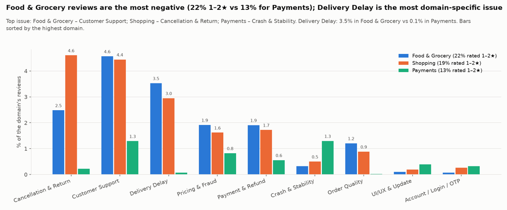

```python
display(Image(REPO / "data/charts/eda/eda_12_domain_comparison.png", width=950))
```

### 4.3 Best and worst app within each domain

Apps are ranked inside their own domain by the share of reviews rated 1–2★, with each app's two most frequent issue tags (% of its reviews).

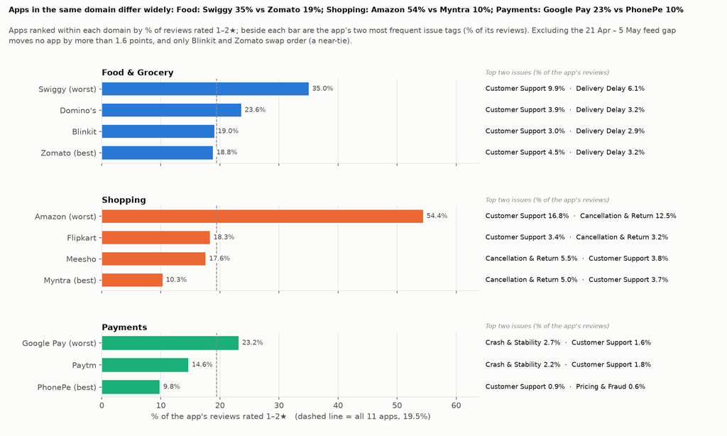

```python
display(Image(REPO / "data/charts/eda/eda_14_within_domain.png", width=950))
```

**Finding 4.** Apps in the same domain differ widely: Swiggy 35.0% against Zomato 18.8% (Food & Grocery), Amazon 54.4% against Myntra 10.3% (Shopping), Google Pay 23.2% against PhonePe 9.8% (Payments). Swiggy has about twice Zomato's Customer Support and Delivery Delay rates; the two weaker payment apps lead with Crash & Stability. **Business meaning:** each team has a different first fix. Blinkit and Zomato are a near-tie (excluding the late-April feed gap swaps them), and these are comparisons of written reviews, not proof of cause.

### 4.4 What are the complaints about? Service or app?

A late delivery or a refused return is a service problem, not an app failure. Each 1–2★ review is placed in one group using its issue tags. Service = delivery, order quality, cancellation/return, support, pricing; app = crash, login/OTP, UI/update. Payment & Refund can be the app, a bank or a gateway, so it is a separate group.

```python
app_t = ["issue_crash_bugs_stability", "issue_account_login_otp", "issue_ui_ux_update"]
svc_t = ["issue_delivery_delay", "issue_order_quality_fulfillment", "issue_cancellation_return", "issue_customer_support", "issue_pricing_charges_fraud"]
low = tagged[tagged["is_problematic"] == 1]
has_app, has_svc = low[app_t].max(axis=1) == 1, low[svc_t].max(axis=1) == 1
group = np.select([has_svc & ~has_app, has_svc & has_app, has_app & ~has_svc, low["issue_payment_refund"] == 1],
                  ["Service issue only", "Service and app issue", "App issue only", "Payment & Refund only"], "No issue tag")
share = (pd.Series(group).value_counts(normalize=True) * 100).round(1)
print(share.to_string())
tagged_low = (group != "No issue tag").sum()
print(f"\nAmong the {tagged_low:,} tagged 1-2 star reviews: {has_svc.sum() / tagged_low:.0%} name a service issue, {has_app.sum() / tagged_low:.0%} an app issue")
```

```
No issue tag             54.3
Service issue only       40.5
App issue only            2.0
Payment & Refund only     1.9
Service and app issue     1.3

Among the 101,279 tagged 1-2 star reviews: 91% name a service issue, 7% an app issue
```

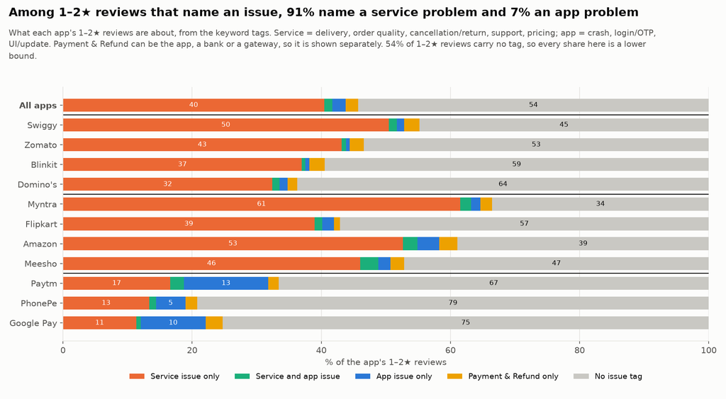

```python
display(Image(REPO / "data/charts/eda/eda_15_complaint_attribution.png", width=950))
```

**Finding 5.** Among 1–2★ reviews that name an issue, about 91% name a service problem and about 7% an app problem. This is why the classifier finds *dissatisfied users*, not software failures. The payment apps are the exception: app-only tags are 13% of Paytm's and 10% of Google Pay's 1–2★ reviews, against 1–3% at the food and shopping apps. **Business meaning:** route app complaints to engineering and delivery, returns and support complaints to operations. 54% of 1–2★ reviews carry no tag (many are just "bad"), so these shares are lower bounds from keyword rules, not human labels.

### 4.5 A collection artefact: the late-April feed gap

```python
day = tagged["review_date"].dt.normalize()
periods = {"before (8-20 Apr)": ("2026-04-08", "2026-04-20"), "gap (21 Apr-5 May)": ("2026-04-21", "2026-05-05"),
           "after (6-18 May)": ("2026-05-06", "2026-05-18")}
rows = {}
for name, (a, b) in periods.items():
    w = tagged[(day >= a) & (day <= b)]
    n_days = (pd.Timestamp(b) - pd.Timestamp(a)).days + 1
    rows[("positive/day", name)] = w[w["score"] >= 4].groupby("app_name").size() / n_days
    rows[("negative/day", name)] = w[w["score"] <= 2].groupby("app_name").size() / n_days
pd.DataFrame(rows).loc[APP_NAMES].round(0)
```

| app_name | positive/day before (8-20 Apr) | negative/day before (8-20 Apr) | positive/day gap (21 Apr-5 May) | negative/day gap (21 Apr-5 May) | positive/day after (6-18 May) | negative/day after (6-18 May) |
| --- | --- | --- | --- | --- | --- | --- |
| Swiggy | 297.0 | 163.0 | 30.0 | 136.0 | 325.0 | 184.0 |
| Zomato | 1061.0 | 186.0 | 762.0 | 128.0 | 753.0 | 172.0 |
| Blinkit | 966.0 | 226.0 | 415.0 | 213.0 | 1198.0 | 290.0 |
| Domino's | 180.0 | 72.0 | 31.0 | 47.0 | 214.0 | 68.0 |
| Myntra | 443.0 | 53.0 | 355.0 | 40.0 | 439.0 | 40.0 |
| Flipkart | 1254.0 | 257.0 | 162.0 | 178.0 | 1557.0 | 309.0 |
| Amazon | 103.0 | 96.0 | 42.0 | 97.0 | 100.0 | 105.0 |
| Meesho | 491.0 | 102.0 | 446.0 | 103.0 | 452.0 | 100.0 |
| Paytm | 205.0 | 28.0 | 112.0 | 31.0 | 204.0 | 51.0 |
| PhonePe | 513.0 | 52.0 | 454.0 | 46.0 | 511.0 | 50.0 |
| Google Pay | 72.0 | 35.0 | 93.0 | 35.0 | 108.0 | 46.0 |

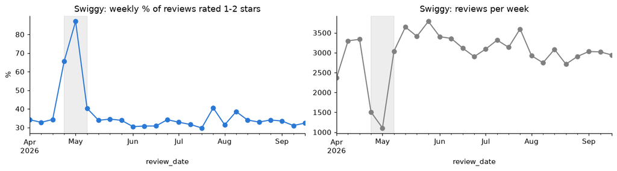

```python
sw = tagged[tagged["app_name"] == "Swiggy"].set_index("review_date").sort_index()
weekly = sw.resample("W-SUN").agg({"is_problematic": "mean", "score": "size"}).rename(columns={"score": "reviews"})
fig, ax = plt.subplots(1, 2, figsize=(12, 3.4))
weekly["is_problematic"].mul(100).plot(ax=ax[0], marker="o", color=APP_COLORS["Swiggy"])
ax[0].set_title("Swiggy: weekly % of reviews rated 1-2 stars"); ax[0].set_ylabel("%")
weekly["reviews"].plot(ax=ax[1], marker="o", color="grey"); ax[1].set_title("Swiggy: reviews per week")
for a in ax:
    a.axvspan(pd.Timestamp("2026-04-21"), pd.Timestamp("2026-05-06"), color="black", alpha=0.07)
plt.tight_layout(); plt.show()
```

**Finding 3.** From 21 April to 5 May 2026 positive reviews fall 59–90% for Swiggy, Blinkit, Domino's, Flipkart and Amazon, while negative reviews fall only 3–37%. Swiggy's "% negative" therefore jumps to ~87% for one week. Negative reviews did not rise, so this is not a wave of complaints, and a scraper failure would remove all reviews alike, so this is on the Play Store side. **Business meaning:** a "% negative" dashboard would raise a false alarm here; counting negative reviews per day is far less affected. We keep these rows, flag them, and leave them out of trend comparisons. (We also checked whether the review mix shifts partway through the window: after 1 July no app's reviews per day rise by 50% or more (ratios 0.63–1.05) and median length is unchanged in 10 of 11 apps, so a time-based test split is safe — see the mid-year check in 4.6.)

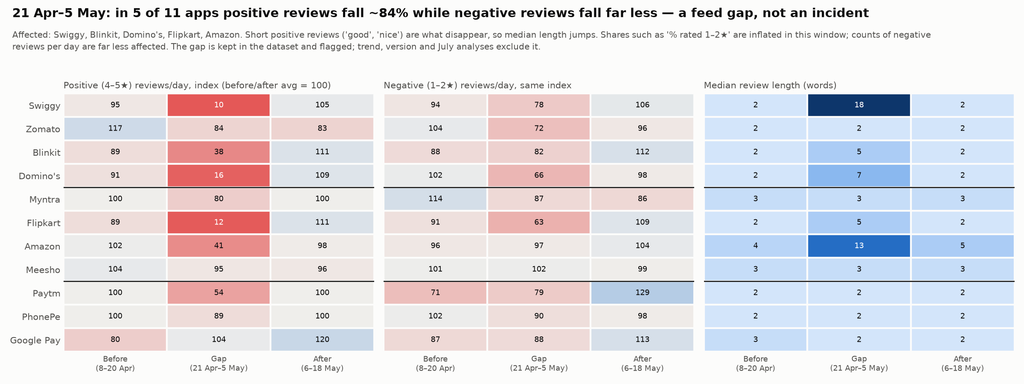

```python
display(Image(REPO / "data/charts/eda/eda_13_april_gap.png", width=950))
```

### 4.6 Other checks

```python
print("Median words by star rating:", tagged.groupby("score")["review_length"].median().to_dict())
up = tagged.groupby("score")["thumbs_up"].sum() / tagged["thumbs_up"].sum() * 100
print("Share of all upvotes by star rating (%):", up.round(1).to_dict())
print("Spearman correlations with rating:")
print(tagged[["score", "sentiment_compound", "issue_count", "review_length"]].corr(method="spearman")["score"].round(3))
```

```
Median words by star rating: {1: 14.0, 2: 4.0, 3: 2.0, 4: 2.0, 5: 2.0}
Share of all upvotes by star rating (%): {1: 59.2, 2: 5.0, 3: 4.5, 4: 12.6, 5: 18.7}
Spearman correlations with rating:
```

```
score                 1.000
sentiment_compound    0.488
issue_count          -0.496
review_length        -0.391
Name: score, dtype: float64
```

**Mid-year check.** Does the review mix shift partway through the window? If it did, a time-based train/test split would be unreliable. Reviews per day and median length per app, April–June against July–September (feed-gap days excluded):

```python
d = tagged[~tagged["review_date"].dt.normalize().between("2026-04-21", "2026-05-05")].copy()   # drop the feed-gap days
d["period"] = np.where(d["review_date"] < "2026-07-01", "Apr-Jun", "Jul-Sep")
days = d.groupby("period")["review_date"].apply(lambda s: s.dt.normalize().nunique())
g = d.groupby(["app_name", "period"]).agg(n=("score", "size"), med_len=("review_length", "median")).unstack()
chk = pd.DataFrame({"per day Apr-Jun": g["n"]["Apr-Jun"] / days["Apr-Jun"], "per day Jul-Sep": g["n"]["Jul-Sep"] / days["Jul-Sep"],
                    "median words Apr-Jun": g["med_len"]["Apr-Jun"], "median words Jul-Sep": g["med_len"]["Jul-Sep"]}).loc[APP_NAMES]
chk["volume ratio"] = chk["per day Jul-Sep"] / chk["per day Apr-Jun"]
print("Apps whose reviews per day rise by 50% or more after 1 July:", int((chk["volume ratio"] >= 1.5).sum()))
chk.round(2)
```

```
Apps whose reviews per day rise by 50% or more after 1 July: 0
```

| app_name | per day Apr-Jun | per day Jul-Sep | median words Apr-Jun | median words Jul-Sep | volume ratio |
| --- | --- | --- | --- | --- | --- |
| Swiggy | 480.95 | 435.20 | 2.0 | 2.0 | 0.90 |
| Zomato | 1072.71 | 673.66 | 2.0 | 2.0 | 0.63 |
| Blinkit | 1411.57 | 1358.62 | 2.0 | 2.0 | 0.96 |
| Domino's | 274.32 | 263.51 | 2.0 | 2.0 | 0.96 |
| Myntra | 501.28 | 503.22 | 3.0 | 3.0 | 1.00 |
| Flipkart | 1673.08 | 1632.02 | 2.0 | 2.0 | 0.98 |
| Amazon | 200.42 | 187.56 | 5.0 | 8.0 | 0.94 |
| Meesho | 593.51 | 600.20 | 3.0 | 3.0 | 1.01 |
| Paytm | 261.82 | 275.24 | 2.0 | 2.0 | 1.05 |
| PhonePe | 540.99 | 483.21 | 2.0 | 2.0 | 0.89 |
| Google Pay | 118.75 | 112.89 | 2.0 | 2.0 | 0.95 |

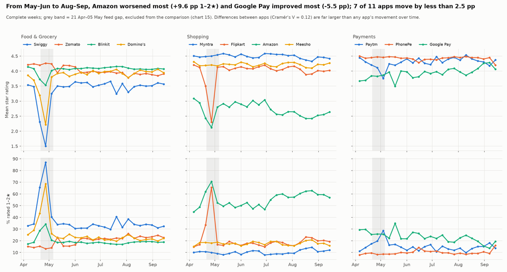

```python
display(Image(REPO / "data/charts/eda/eda_10_weekly_trend.png", width=950))
```

**Review length and upvotes (chart 03).** Complaints are long and praise is short (median 14 words for 1★ against 2 for 5★), and other users upvote complaints: 1★ reviews are 17% of reviews but 59% of upvotes.

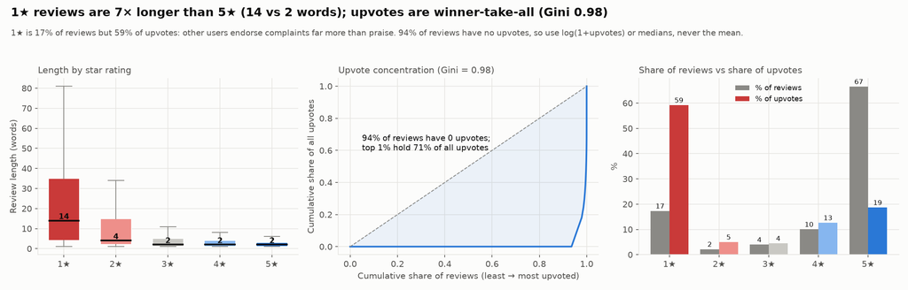

```python
display(Image(REPO / "data/charts/eda/eda_03_length_and_upvotes.png", width=950))
```

**Correlations (chart 04).** Rating and VADER sentiment move together (ρ = 0.49); more issue tags go with lower ratings (ρ = −0.50) and with longer text (ρ = 0.46). This is why sentiment and review length are model features.

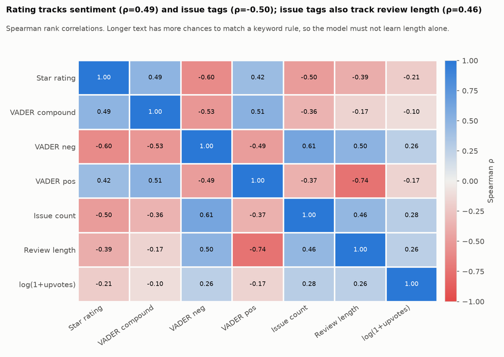

```python
display(Image(REPO / "data/charts/eda/eda_04_correlation_matrix.png", width=950))
```

### 4.7 App versions: a first look at update impact

Each app version with at least 30 reviews is compared with its app's average rating (feed-gap days excluded). A version is flagged only if it is at least 0.25★ away from the app mean **and** |z| ≥ 3.

```python
vt = pd.read_csv(REPO / "data" / "eda" / "version_metrics.csv")
worse = vt[vt["flag"] == "worse than app average"]
print(f"{len(vt)} app versions with at least 30 reviews: {len(worse)} rate clearly worse than their app mean, "
      f"{int((vt['flag'] == 'better than app average').sum())} clearly better.")
worse.groupby("app_name").size().sort_values(ascending=False).to_frame("worse versions").T
```

```
544 app versions with at least 30 reviews: 49 rate clearly worse than their app mean, 17 clearly better.
```

| app_name | Flipkart | Zomato | Amazon | PhonePe | Swiggy | Google Pay | Paytm | Blinkit | Meesho | Myntra |
| --- | --- | --- | --- | --- | --- | --- | --- | --- | --- | --- |
| worse versions | 15 | 7 | 5 | 5 | 5 | 4 | 3 | 2 | 2 | 1 |

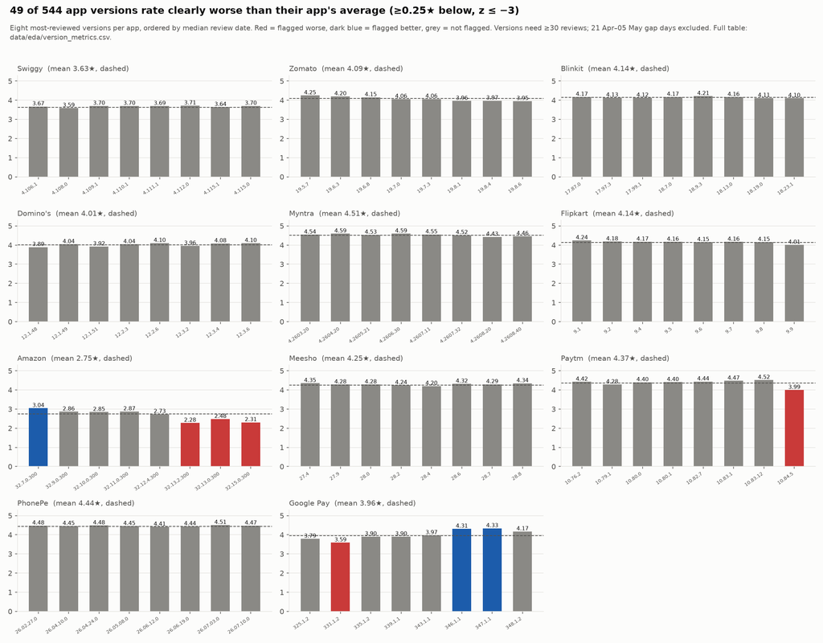

```python
display(Image(REPO / "data/charts/eda/eda_11_app_versions.png", width=950))
```

**Finding 6.** Flagged versions are concentrated (Flipkart has the most). Every Amazon version first seen since mid-July (32.13 to 32.17) rates 2.28–2.48★ against the app mean of 2.75★. **Caution:** a review is attributed to the reviewer's *installed* version, not the release that caused the complaint, and version is confounded with time, so treat this as a shortlist for investigation, not proof.

### 4.8 Supporting checks

**Issue co-occurrence (chart 07).** Crash and UI/UX tags co-occur about 26 times more than chance (n = 281), which points to post-update breakage; Payment & Refund travels with Cancellation & Return (13.3x) and Order Quality (13.1x).

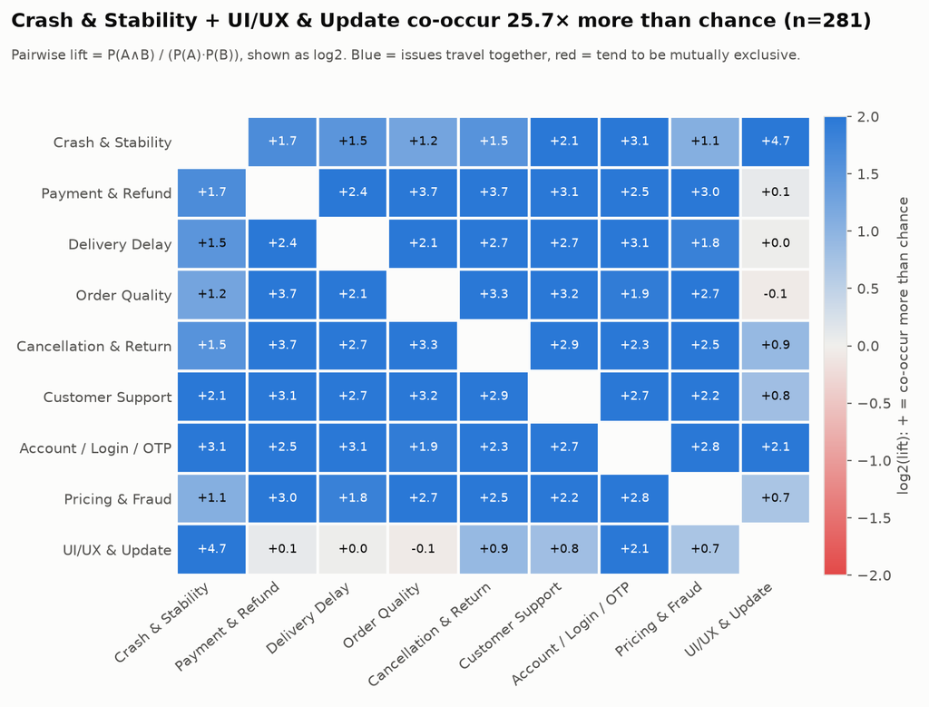

```python
display(Image(REPO / "data/charts/eda/eda_07_issue_cooccurrence.png", width=950))
```

**How good are the issue tags? (charts 08 and 09).** Tags track the rating (49% of 1★ reviews carry a tag against 1% of 5★), but keyword rules ignore polarity: 3,135 five-star reviews carry the Cancellation & Return tag (40% Myntra, praise such as "easy returns"). 54% of 1–2★ reviews carry no tag, and the most distinctive untagged terms are praise words ("nice product", "mast", "super"), i.e. mis-ratings. Tag shares are therefore lower bounds.

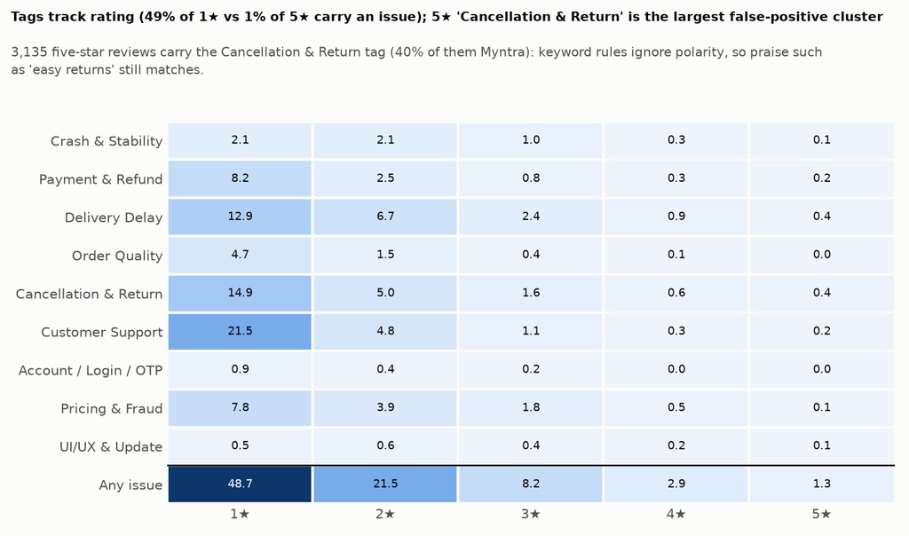

```python
display(Image(REPO / "data/charts/eda/eda_08_issue_by_rating.png", width=950))
```

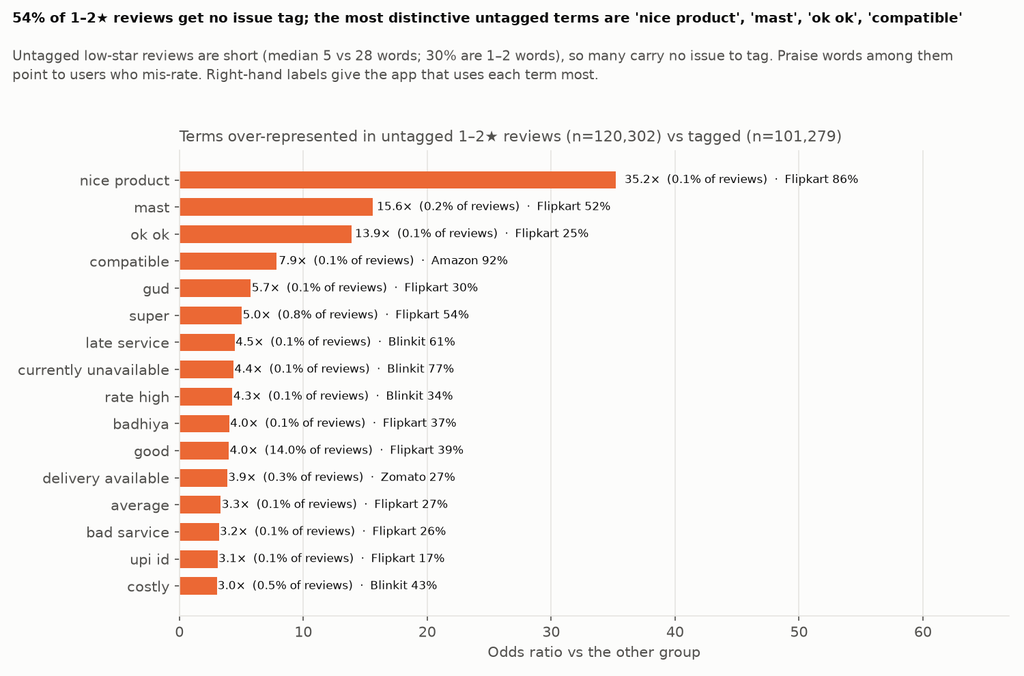

```python
display(Image(REPO / "data/charts/eda/eda_09_taxonomy_gap.png", width=950))
```

## 5. Feature engineering and dimensionality reduction

- **Text:** TF-IDF (20,000 terms, single words and 2-word phrases, sublinear term frequency, min_df 3, max_df 0.95, **no stop-word list** so negations such as "not good" are kept), then **Truncated SVD** to 200 components.
- **Structural (15):** 9 issue flags, 4 VADER scores, `review_length`, `thumbs_up` — scaled with `StandardScaler`.
- **Total:** 215 features. Same settings as `scripts/05_feature_engineering.py`.

```python
from sklearn.feature_extraction.text import TfidfVectorizer
from sklearn.decomposition import TruncatedSVD
from sklearn.preprocessing import StandardScaler

structural_cols = [f"issue_{i}" for i in ISSUES] + ["sentiment_neg", "sentiment_neu", "sentiment_pos", "sentiment_compound",
                                                     "review_length", "thumbs_up"]
y = tagged["is_problematic"].to_numpy()
print(f"Target: {y.sum():,} problematic ({y.mean()*100:.1f}%), {(1-y).sum():,} not problematic")

t0 = time.time()
tfidf = TfidfVectorizer(max_features=20000, ngram_range=(1, 2), min_df=3, max_df=0.95, sublinear_tf=True, dtype=np.float32)
X_tfidf = tfidf.fit_transform(tagged["content"].fillna("").astype(str))
svd = TruncatedSVD(n_components=200, random_state=42)
X_svd = svd.fit_transform(X_tfidf)
X_struct = StandardScaler().fit_transform(tagged[structural_cols].fillna(0).astype(float))
X = np.hstack([X_svd, X_struct]).astype(np.float32)
feature_names = [f"SVD_{i}" for i in range(200)] + structural_cols
print(f"TF-IDF {X_tfidf.shape} -> SVD {X_svd.shape} (keeps {svd.explained_variance_ratio_.sum()*100:.1f}% of variance)")
print(f"Final feature matrix: {X.shape}   ({time.time()-t0:.0f}s)")
```

```
Target: 221,581 problematic (19.5%), 916,406 not problematic
```

```
TF-IDF (1137987, 20000) -> SVD (1137987, 200) (keeps 62.7% of variance)
Final feature matrix: (1137987, 215)   (52s)
```

```python
terms = np.array(tfidf.get_feature_names_out())
for k in range(4):
    comp = svd.components_[k]
    print(f"SVD_{k}: + {', '.join(terms[np.argsort(-comp)[:6]])}")
```

```
SVD_0: + good, very good, very, good service, good app, service
SVD_1: + nice, very nice, very, nice app, app, very good
SVD_2: + very good, very, very nice, app, good app, service
SVD_3: + best, super, app, best app, good app, nice app
```

**Justification.** A 1.1-million × 20,000 sparse matrix is slow and noisy for a Random Forest; SVD gives a compact dense representation (100× fewer text columns). Issue flags and sentiment add meaning single words miss; `review_length` is kept explicitly because complaints are much longer than praise (14 vs 2 words median).

**Effect.** 20,000 → 200 text columns while keeping ~63% of the TF-IDF variance (most reviews use a small vocabulary).

## 6. Predictive model development

- **Task:** binary classification of `is_problematic`.
- **Models:** Logistic Regression (simple, interpretable baseline) and Random Forest (non-linear interactions, feature importance); both with `class_weight="balanced"` because only 19.5% of reviews are problematic.
- **Split:** stratified 80/20, `random_state=42`.
- **Random Forest settings:** 150 trees, each on a 30% bootstrap sample, `min_samples_leaf=100` — keeps the model small (≈10 MB) on 910k training rows.
- **Settings check:** `C` and `min_samples_leaf` were compared on a validation split of the training data, never the test set (Section 7.4).

```python
from sklearn.model_selection import train_test_split
from sklearn.linear_model import LogisticRegression
from sklearn.ensemble import RandomForestClassifier
from sklearn.metrics import (accuracy_score, precision_score, recall_score, f1_score, roc_auc_score,
                             average_precision_score, confusion_matrix, precision_recall_curve, roc_curve)

idx_train, idx_test = train_test_split(np.arange(len(y)), test_size=0.20, random_state=42, stratify=y)
X_train, X_test, y_train, y_test = X[idx_train], X[idx_test], y[idx_train], y[idx_test]
print(f"Train {len(y_train):,} / Test {len(y_test):,}; problematic share train {y_train.mean():.3f}, test {y_test.mean():.3f}")

def make_models():
    return {"Logistic Regression": LogisticRegression(max_iter=1000, class_weight="balanced", random_state=42),
            "Random Forest": RandomForestClassifier(n_estimators=150, max_samples=0.3, min_samples_leaf=100,
                                                    class_weight="balanced", random_state=42, n_jobs=-1)}

def scores(y_true, y_pred, y_prob):
    return {"accuracy": accuracy_score(y_true, y_pred), "precision": precision_score(y_true, y_pred, zero_division=0),
            "recall": recall_score(y_true, y_pred), "f1": f1_score(y_true, y_pred),
            "roc_auc": roc_auc_score(y_true, y_prob), "pr_auc": average_precision_score(y_true, y_prob)}

models, probs, preds, results = make_models(), {}, {}, {}
results["Majority-class baseline"] = scores(y_test, np.zeros_like(y_test), np.zeros(len(y_test)))
for name, m in models.items():
    t0 = time.time(); m.fit(X_train, y_train)
    probs[name] = m.predict_proba(X_test)[:, 1]; preds[name] = m.predict(X_test)
    results[name] = scores(y_test, preds[name], probs[name])
    print(f"{name}: trained in {time.time()-t0:.0f}s")
```

```
Train 910,389 / Test 227,598; problematic share train 0.195, test 0.195
```

```
Logistic Regression: trained in 13s
```

```
Random Forest: trained in 111s
```

## 7. Model evaluation and result interpretation

Classification metrics: accuracy, precision, recall, F1, confusion matrix, plus ROC-AUC and PR-AUC. (R², MAE, MSE and RMSE are regression metrics and do not apply to this classifier.)

```python
res = pd.DataFrame(results).T.round(4)
res
```

|  | accuracy | precision | recall | f1 | roc_auc | pr_auc |
| --- | --- | --- | --- | --- | --- | --- |
| Majority-class baseline | 0.8053 | 0.0000 | 0.0000 | 0.0000 | 0.5000 | 0.1947 |
| Logistic Regression | 0.9214 | 0.7666 | 0.8578 | 0.8096 | 0.9401 | 0.8708 |
| Random Forest | 0.9145 | 0.7379 | 0.8700 | 0.7985 | 0.9410 | 0.8735 |

**Note on reproducibility.** The numbers quoted in the report and slides come from `scripts/06_model_training.py` (`data/model_results.csv`). This notebook retrains the models itself, and on a different machine the results agree to within about 0.001 (for example Logistic Regression accuracy 0.9214 here against 0.9216 in `data/model_results.csv`; Random Forest PR-AUC 0.8735 in both). The small differences come from the randomised SVD and the solvers, which are not bit-identical across library builds; none of the conclusions change.

Side-by-side comparison of the two models and the baseline on the test set:

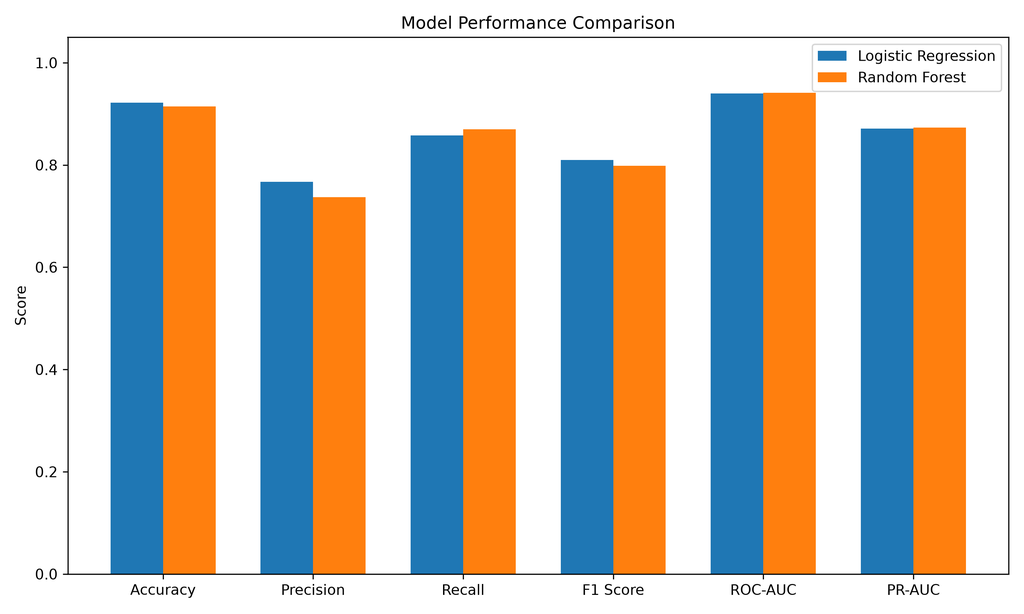

```python
display(Image(REPO / "figures/model_performance_comparison.png", width=950))
```

```python
cms = {n: confusion_matrix(y_test, p) for n, p in preds.items()}
pd.DataFrame({n: {"true negative": c[0, 0], "false positive": c[0, 1], "false negative": c[1, 0], "true positive": c[1, 1]}
              for n, c in cms.items()}).T
```

|  | true negative | false positive | false negative | true positive |
| --- | --- | --- | --- | --- |
| Logistic Regression | 171706 | 11576 | 6303 | 38013 |
| Random Forest | 169585 | 13697 | 5760 | 38556 |

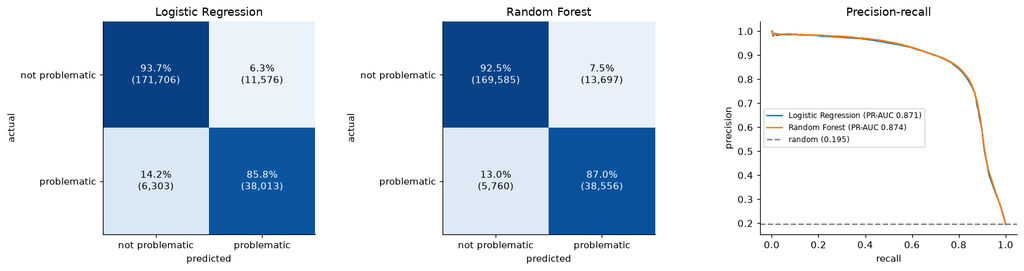

```python
fig, ax = plt.subplots(1, 3, figsize=(15, 4))
for k, (name, c) in enumerate(cms.items()):
    cn = c / c.sum(axis=1, keepdims=True)
    ax[k].imshow(cn, cmap="Blues", vmin=0, vmax=1)
    for i in range(2):
        for j in range(2):
            ax[k].text(j, i, f"{cn[i, j]:.1%}\n({c[i, j]:,})", ha="center", va="center", color="white" if cn[i, j] > .5 else "black")
    ax[k].set_xticks([0, 1], ["not problematic", "problematic"]); ax[k].set_yticks([0, 1], ["not problematic", "problematic"])
    ax[k].set_xlabel("predicted"); ax[k].set_ylabel("actual"); ax[k].set_title(name)
for name in probs:
    p, r, _ = precision_recall_curve(y_test, probs[name]); ax[2].plot(r, p, label=f"{name} (PR-AUC {results[name]['pr_auc']:.3f})")
ax[2].axhline(y_test.mean(), ls="--", color="grey", label=f"random ({y_test.mean():.3f})")
ax[2].set_xlabel("recall"); ax[2].set_ylabel("precision"); ax[2].set_title("Precision-recall"); ax[2].legend(fontsize=8)
plt.tight_layout(); plt.show()
```

ROC curves for both models (ROC-AUC 0.94 each; the curves almost overlap):

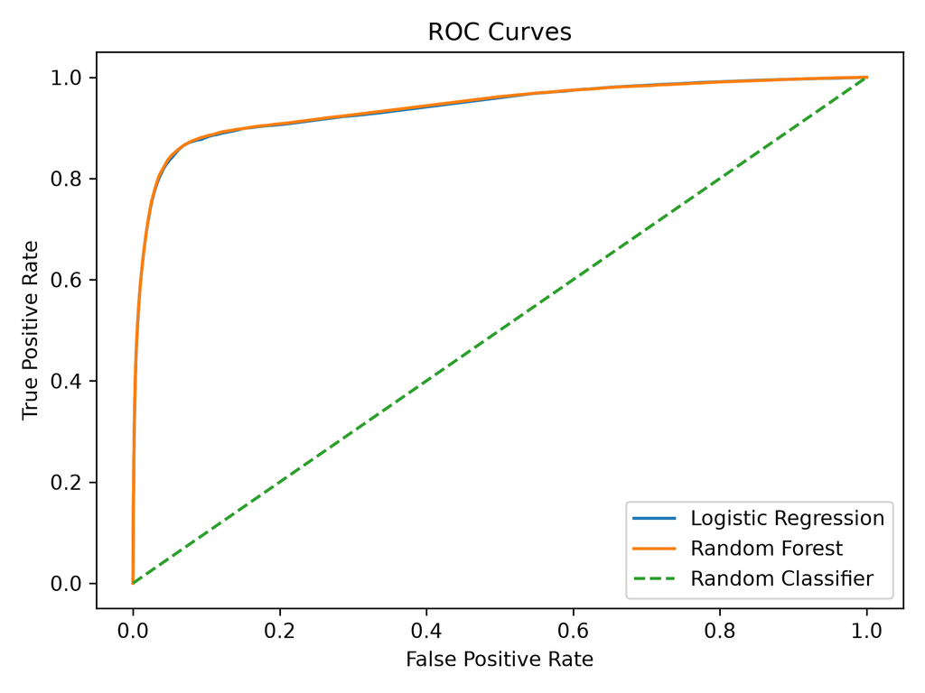

```python
display(Image(REPO / "figures/roc_curves.png", width=950))
```

Saved figures from `scripts/07` and `scripts/12`: the normalised confusion matrices and the precision-recall curves.

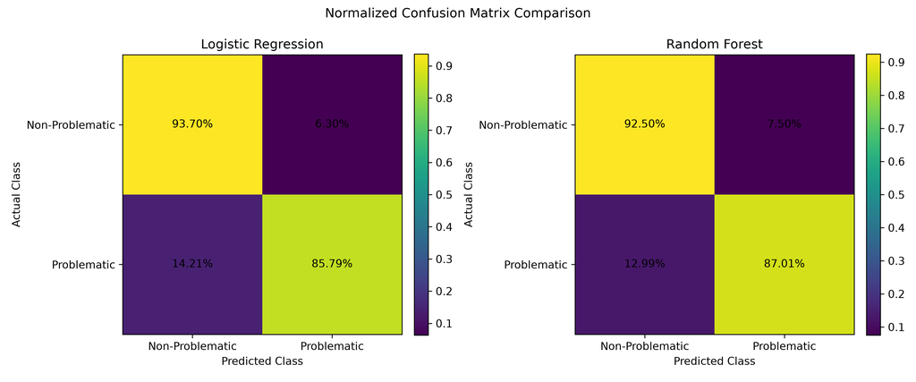

```python
display(Image(REPO / "figures/normalized_confusion_matrix_comparison.png", width=950))
```

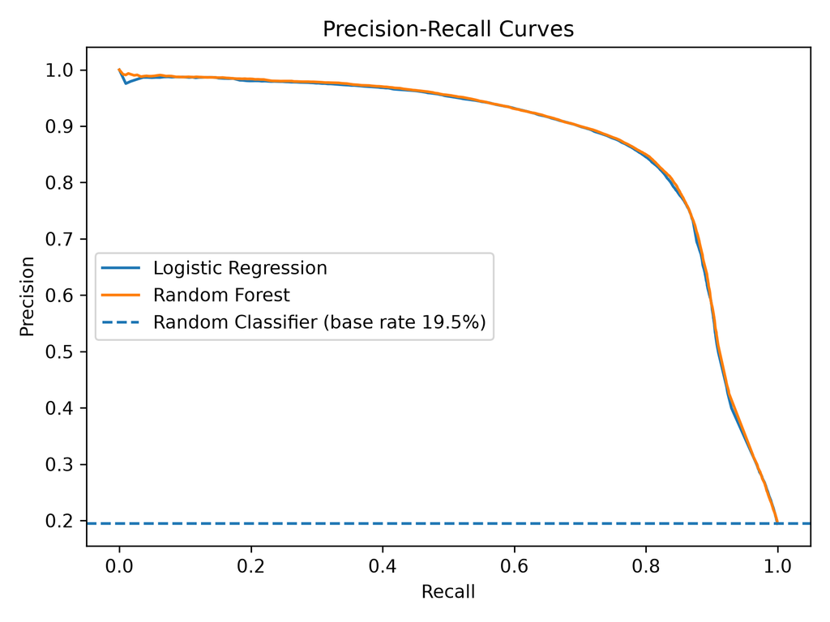

```python
display(Image(REPO / "figures/precision_recall_curves.png", width=950))
```

### 7.1 Where does the model work best? (Random Forest, by domain and app)

```python
test = tagged.iloc[idx_test][["app_name", "domain"]].reset_index(drop=True)
test["y"], test["pred"], test["prob"] = y_test, preds["Random Forest"], probs["Random Forest"]
def grp(g):
    return pd.Series({"test reviews": len(g), "% problematic": g["y"].mean() * 100,
                      "precision": precision_score(g["y"], g["pred"]), "recall": recall_score(g["y"], g["pred"]),
                      "pr_auc": average_precision_score(g["y"], g["prob"])})
pd.concat([test.groupby("domain").apply(grp, include_groups=False), test.groupby("app_name").apply(grp, include_groups=False)]).round(3)
```

|  | test reviews | % problematic | precision | recall | pr_auc |
| --- | --- | --- | --- | --- | --- |
| Food & Grocery | 99491.0 | 21.745 | 0.739 | 0.905 | 0.895 |
| Payments | 30747.0 | 12.860 | 0.625 | 0.806 | 0.751 |
| Shopping | 97360.0 | 19.236 | 0.764 | 0.843 | 0.869 |
| Amazon | 6705.0 | 54.825 | 0.908 | 0.960 | 0.968 |
| Blinkit | 45707.0 | 18.953 | 0.666 | 0.906 | 0.866 |
| Domino's | 8568.0 | 23.938 | 0.785 | 0.889 | 0.898 |
| Flipkart | 53192.0 | 18.117 | 0.771 | 0.742 | 0.800 |
| Google Pay | 4049.0 | 23.388 | 0.682 | 0.857 | 0.812 |
| Meesho | 20509.0 | 17.826 | 0.694 | 0.943 | 0.909 |
| Myntra | 16954.0 | 10.375 | 0.658 | 0.950 | 0.926 |
| Paytm | 9026.0 | 14.359 | 0.661 | 0.840 | 0.799 |
| PhonePe | 17672.0 | 9.682 | 0.568 | 0.750 | 0.680 |
| Swiggy | 15001.0 | 35.151 | 0.873 | 0.934 | 0.948 |
| Zomato | 30215.0 | 18.689 | 0.740 | 0.881 | 0.879 |

### 7.2 Does it work on future weeks? (train April–August, test 1–20 September)

```python
past = (tagged["review_date"] < "2026-09-01").to_numpy()
oot = {}
for name, m in make_models().items():
    m.fit(X[past], y[past]); prob = m.predict_proba(X[~past])[:, 1]
    oot[name] = scores(y[~past], (prob >= 0.5).astype(int), prob)
print(f"train {past.sum():,} reviews (Apr-Aug), test {(~past).sum():,} reviews (1-20 Sep)")
pd.DataFrame(oot).T.round(4)
```

```
train 1,008,932 reviews (Apr-Aug), test 129,055 reviews (1-20 Sep)
```

|  | accuracy | precision | recall | f1 | roc_auc | pr_auc |
| --- | --- | --- | --- | --- | --- | --- |
| Logistic Regression | 0.9121 | 0.7475 | 0.8482 | 0.7947 | 0.9375 | 0.8625 |
| Random Forest | 0.9047 | 0.7189 | 0.8623 | 0.7841 | 0.9389 | 0.8660 |

### 7.3 What drives the predictions?

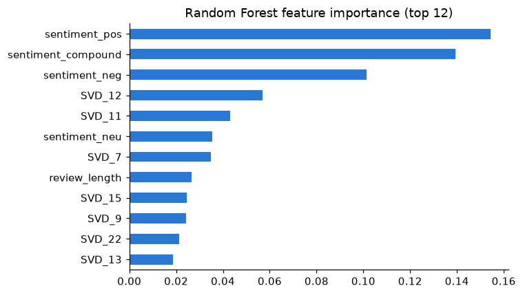

|  | sentiment_pos | sentiment_compound | sentiment_neg | SVD_12 | SVD_11 | sentiment_neu | SVD_7 | review_length |
| --- | --- | --- | --- | --- | --- | --- | --- | --- |
| importance | 0.154 | 0.139 | 0.101 | 0.057 | 0.043 | 0.035 | 0.035 | 0.027 |

```python
imp = pd.Series(models["Random Forest"].feature_importances_, index=feature_names).sort_values(ascending=False)
ax = imp.head(12)[::-1].plot.barh(figsize=(7, 4), color="#2a78d6", title="Random Forest feature importance (top 12)")
plt.tight_layout(); plt.show()
imp.head(8).round(3).to_frame("importance").T
```

Saved figure from `scripts/08_model_interpretation.py`: blue bars are named features, grey bars are the anonymous SVD text components.

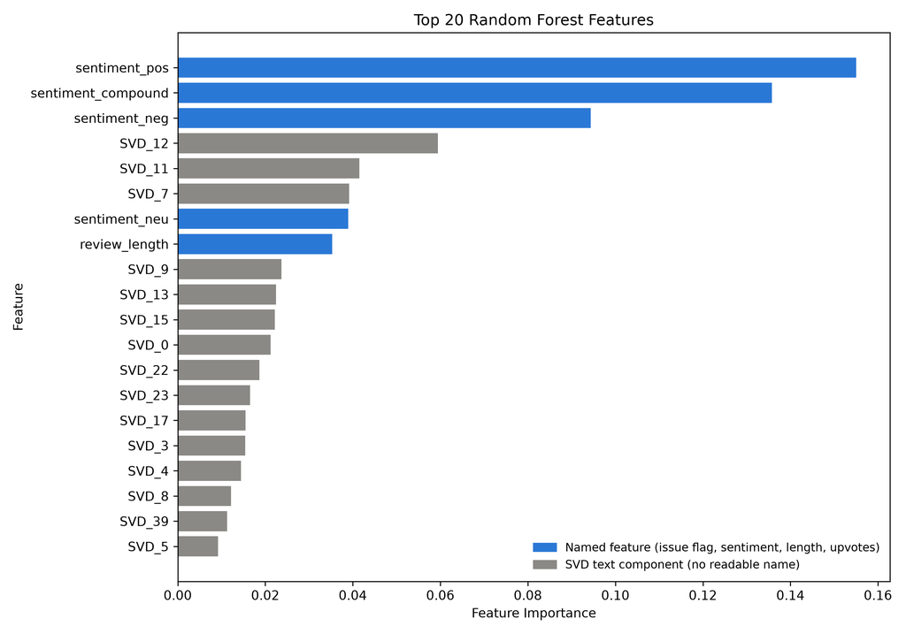

```python
display(Image(REPO / "figures/random_forest_feature_importance.png", width=950))
```

**Terms behind the text components.** The terms with the largest SVD loadings mix praise ("very fast", "the best") and complaint phrases ("very bad", "not good", "worst app"). Terms made only of stop words are hidden in this chart; they stay in the model.

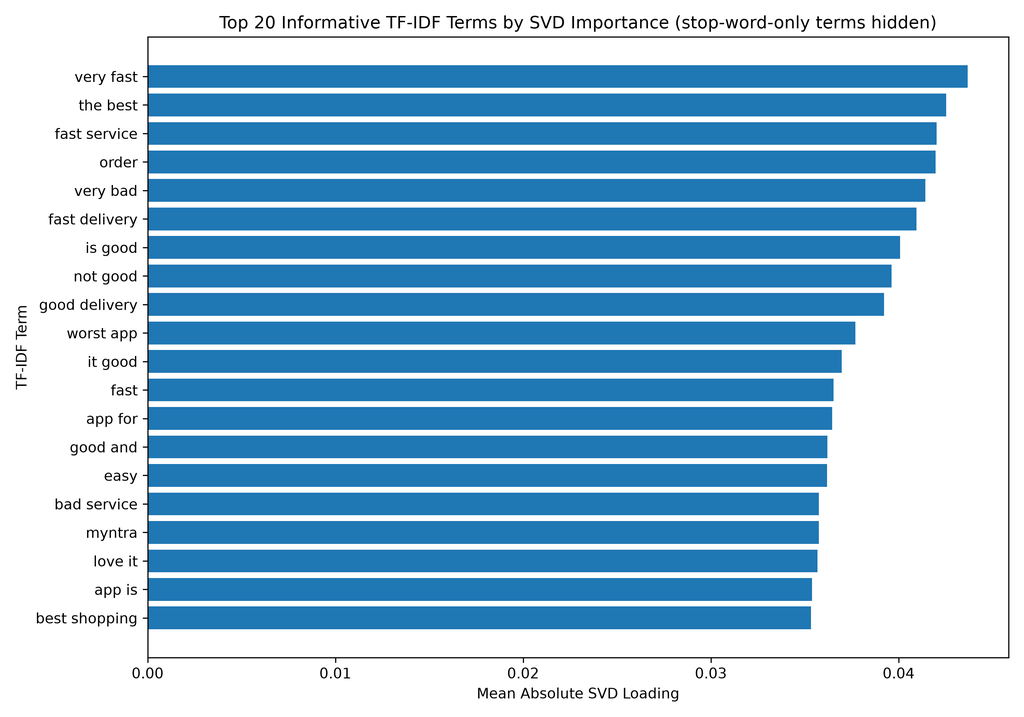

```python
display(Image(REPO / "figures/top_tfidf_terms.png", width=950))
```

### 7.4 Robustness checks

`scripts/13_model_robustness_checks.py` takes about 20 minutes on 20 cores, so the notebook reads its saved results. It computes 95% bootstrap intervals on the test set, retrains both models on parts of the feature set (ablation), and compares settings on a validation split of the training data (the test set is not used to choose settings).

```python
ci = pd.read_csv(REPO / "data" / "model_bootstrap_ci.csv")
ablation = pd.read_csv(REPO / "data" / "model_ablation.csv")
tuning = pd.read_csv(REPO / "data" / "model_tuning.csv")

display(ci[ci["metric"].isin(["accuracy", "f1_score", "pr_auc"])].round(4))
order = ["text_only", "sentiment_only", "structural_only", "all_except_sentiment", "all_features"]
display(ablation.pivot(index="features", columns="model", values="pr_auc").loc[order].round(4))
tuning[["model", "parameter", "value", "current_setting", "pr_auc", "f1_score", "size_vs_current"]].round(4)
```

|  | model | metric | estimate | ci_low | ci_high | ci_half_width |
| --- | --- | --- | --- | --- | --- | --- |
| 0 | logistic_regression | accuracy | 0.9216 | 0.9206 | 0.9227 | 0.0010 |
| 3 | logistic_regression | f1_score | 0.8100 | 0.8073 | 0.8126 | 0.0026 |
| 5 | logistic_regression | pr_auc | 0.8710 | 0.8681 | 0.8738 | 0.0028 |
| 6 | random_forest | accuracy | 0.9143 | 0.9132 | 0.9154 | 0.0011 |
| 9 | random_forest | f1_score | 0.7982 | 0.7955 | 0.8009 | 0.0027 |
| 11 | random_forest | pr_auc | 0.8735 | 0.8708 | 0.8762 | 0.0027 |
| 12 | random_forest_minus_logistic_regression | accuracy | -0.0073 | -0.0080 | -0.0066 | 0.0007 |
| 15 | random_forest_minus_logistic_regression | f1_score | -0.0118 | -0.0132 | -0.0103 | 0.0014 |
| 17 | random_forest_minus_logistic_regression | pr_auc | 0.0025 | 0.0014 | 0.0036 | 0.0011 |

| model features | logistic_regression | random_forest |
| --- | --- | --- |
| text_only | 0.8524 | 0.8542 |
| sentiment_only | 0.7390 | 0.8016 |
| structural_only | 0.8395 | 0.8482 |
| all_except_sentiment | 0.8573 | 0.8569 |
| all_features | 0.8710 | 0.8735 |

|  | model | parameter | value | current_setting | pr_auc | f1_score | size_vs_current |
| --- | --- | --- | --- | --- | --- | --- | --- |
| 0 | logistic_regression | C | 0.01 | False | 0.8607 | 0.7688 | NaN |
| 1 | logistic_regression | C | 0.10 | False | 0.8699 | 0.8071 | NaN |
| 2 | logistic_regression | C | 1.00 | True | 0.8720 | 0.8110 | NaN |
| 3 | logistic_regression | C | 10.00 | False | 0.8719 | 0.8113 | NaN |
| 4 | random_forest | min_samples_leaf | 25.00 | False | 0.8786 | 0.8079 | 2.80 |
| 5 | random_forest | min_samples_leaf | 50.00 | False | 0.8769 | 0.8023 | 1.72 |
| 6 | random_forest | min_samples_leaf | 100.00 | True | 0.8742 | 0.7959 | 1.00 |
| 7 | random_forest | min_samples_leaf | 200.00 | False | 0.8701 | 0.7869 | 0.56 |

**Reading the checks.** The 95% intervals are about ±0.003 PR-AUC, so the test-set score is estimated precisely (this measures test-sampling noise only; the out-of-time test in 7.2 is the check against a different split), and the Random Forest's PR-AUC lead over Logistic Regression (0.001 to 0.004) is small but real. The text components alone (PR-AUC about 0.85) predict better than the sentiment scores alone (0.74–0.80), and every feature group adds to the full model: sentiment tops the importance chart only because each score is one strong column. On validation, `C=1` is the best Logistic Regression setting; 25 reviews per leaf would add only 0.004 PR-AUC to the Random Forest at 2.8× the size, so we keep 100.

### 7.5 Interpretation and business findings

**Strengths**

- Only 19.5% of reviews are problematic, so a model that never flags anything already scores 80.5% accuracy but finds **no** complaints. Accuracy is therefore not the headline — PR-AUC is: **0.87 for both models vs 0.195 for random guessing.** Both are more than 91% accurate.
- The two models are close: Logistic Regression is more precise at the default threshold (precision 0.77 vs 0.74, about 16% fewer false alarms), while the Random Forest finds slightly more complaints (recall 0.87 vs 0.86) and has the slightly higher PR-AUC.
- Training on April–August and testing on 1–20 September costs less than 0.01 PR-AUC, so the models generalise to future weeks.

**Limitations**

- The target is the star rating: the model predicts "low rating", not a confirmed failure. Some users give 1★ with praise text ("nice product"), and some 5★ with complaints.
- Most reviews are 1–3 words, so for them the model mostly reads sentiment; payment apps (rarer, shorter complaints) are the hardest domain.
- TF-IDF/SVD/scaler are fitted before the split (they do not use the target); only two settings were checked on a validation split, not a full search.

**Initial business findings**

1. Triage reviews automatically: the Random Forest catches 87% of complaints with about 3 in 4 flags correct; Logistic Regression catches 86% with about 77% of flags correct. Choose by whether missed complaints or reviewer time cost more.
2. Each app should start with its own top issue: Customer Support and delivery for food apps, returns and support for shopping apps (Amazon worst on almost everything), support and stability for payment apps.
3. Monitor complaints as **counts per day**, not "% negative": the late-April Play Store gap would otherwise trigger a false alarm.

## 8. Where to find everything

| Need | Where |
| --- | --- |
| Dataset source, collection method, parameters, known issues | `DATA_SOURCES.md` |
| Cleaning script and results | `scripts/02_clean_reviews.py`, `data/cleaning_results.json` |
| EDA findings, method and statistical tests | `EDA.md`, `data/eda_summary.json`, 15 charts in `data/charts/eda/` |
| Feature engineering and model results | `MODEL_EVALUATION.md`, `data/model_*.csv`, `figures/` |
| Classify a new review with the saved models | `scripts/14_predict_review.py` |
| Full project report and reproduction steps | `REPORT.md`, `README.md`, `requirements.txt` |